## Analysis of the growth rate of the largest Tranmission lineages and their relation to explanatory variables.

##### Research question: Is the growth and size of transmission lineages in the time period 2010-2017 dependent on any of the explanatory variables: Sex distribution in the clade, mtD status, penA status, or final lineage size (transmissin lineage size)?.

The input for the following analyses are all the transmission lineages containing more than 10 sequences from each location: (Norway, Australia, USA). For each of the transmission lineages we run [skygrowth v.0.3.1](https://github.com/mrc-ide/skygrowth) on the clades, and extract the growth rate of the effective population size in the time interval 2010-2017

### Transmission lineages in Norway

```
## [1] Size of transmission lineages containing more than 10 sequences:
```

```
##  [1] 185 121  90  85  70  57  56  51  27  23  20  18  17  17  14  14  13  12  11
## [20]  11  11  11  11
```

```
## [1] Number of transmission containing more than 10 sequences:
```

```
## [1] 23
```

With estimated arrival times (midpoint of the ancestral branch of the transmission lineage) in Norway:

```
## [1] Estimated arrival time in Norway
```

```
##  [1] 1987.737 2003.177 2007.786 1981.407 2008.687 1945.542 1965.954 2005.998
##  [9] 1942.936 2005.313 2008.090 2002.812 2015.061 2015.741 2008.050 1995.163
## [17] 2006.754 2005.377 1996.370 2000.257 2009.179 1979.664 2011.285
```

From skygrowth we find that the average growth rate of these effective population size of these lineage on the time interval 2010-2017 is:

```
## [1] Average growth rate in 2010-2017:
```

```
##  [1]  0.14957086  0.40586782  0.18823745  0.21193805  1.42939245 -0.06648479
##  [7] -0.08292415  0.37414602 -0.15004728  0.72711437  0.34760232  0.31184957
## [13]  1.95753800  0.23908737  0.59424712 -0.04110421  0.13925043  0.12100560
## [19] -0.16718384          NA  0.45422935 -0.12434018  0.38957345
```

The fourth to the last produces the value “NA”, because this transmission lineage does not exist on the time interval [2010, 2017].

Similarly, for Australia and USA we find:

### Transmission lineages in Australia

```
## [1] Size of transmission lineages containing more than 10 sequences:
```

```
##  [1] 254 195 190 165 125 121  88  81  49  49  46  44  43  41  35  24  20  20  18
## [20]  18  16  15  15  15  14  13  12  12  12  11
```

```
## [1] Number of transmission containing more than 10 sequences:
```

```
## [1] 30
```

```
## [1] Estimated arrival time in Australia
```

```
##  [1] 2009.832 2006.724 2012.104 2000.280 1985.136 2009.195 1999.664 1997.703
##  [9] 2002.988 1993.818 1912.241 1980.317 2012.335 2011.512 2003.826 2013.257
## [17] 2010.635 1974.381 2010.632 2007.702 2004.582 2000.387 2009.536 2005.816
## [25] 2010.210 2011.727 2001.528 2012.804 2005.632 2014.190
```

```
## [1] Average growth rate in 2010-2017:
```

[output not shown]

### Transmission lineages in USA

```
## [1] Size of transmission lineages containing more than 10 sequences:
```

```
##  [1] 446 168 157 127 104  81  62  52  51  45  44  43  41  40  38  38  33  30  29
## [20]  29  27  27  25  25  22  22  19  18  16  15  14  14  13  13  11
```

```
## [1] Number of transmission containing more than 10 sequences:
```

```
## [1] 35
```

```
## [1] Estimated arrival time in USA
```

```
##  [1] 1923.403 1900.930 1967.540 1917.941 1902.333 1997.361 1916.062 1890.556
##  [9] 1923.501 1864.753 1971.060 1909.338 1985.211 1978.712 1939.994 1973.433
## [17] 2001.340 1974.247 1992.234 2001.689 1886.491 2003.135 1945.823 1974.156
## [25] 1966.038 1986.422 1963.833 2008.835 1890.400 1996.932 2002.723 2007.754
## [33] 1982.887 1991.598 2008.687
```

```
## [1] Average growth rate in 2010-2017:
```

[output not shown]

## Metadata

To study the relation of the growth rates to metadata we collect the growth rates in a data frame along with variables that describe the sex distribution, penA status and mtrD status for each transmission lineage.

The dataset now looks like

```
##    GrowthRate locations tlSize       penA        mtr sexDistribution
## 1  0.14957086    Norway    185 non-mosaic non-mosaic       0.9944134
## 2  0.40586782    Norway    121 non-mosaic non-mosaic       0.9666667
## 3  0.18823745    Norway     90 non-mosaic non-mosaic       0.5795455
## 4  0.21193805    Norway     85 non-mosaic non-mosaic       0.9759036
## 5  1.42939245    Norway     70 non-mosaic    mosaic4       0.9565217
## 6 -0.06648479    Norway     57 non-mosaic non-mosaic       0.8596491
```

```
## 'data.frame':    88 obs. of  6 variables:
##  $ GrowthRate     : num  0.15 0.406 0.188 0.212 1.429 ...
##  $ locations      : chr  "Norway" "Norway" "Norway" "Norway" ...
##  $ tlSize         : num  185 121 90 85 70 57 56 51 27 23 ...
##  $ penA           : chr  "non-mosaic" "non-mosaic" "non-mosaic" "non-mosaic" ...
##  $ mtr            : chr  "non-mosaic" "non-mosaic" "non-mosaic" "non-mosaic" ...
##  $ sexDistribution: num  0.994 0.967 0.58 0.976 0.957 ...
```

## Modeling the growth rates and lineage sizes on the metadata

The growth rates and lineage size may are the two quantities we seek to explain

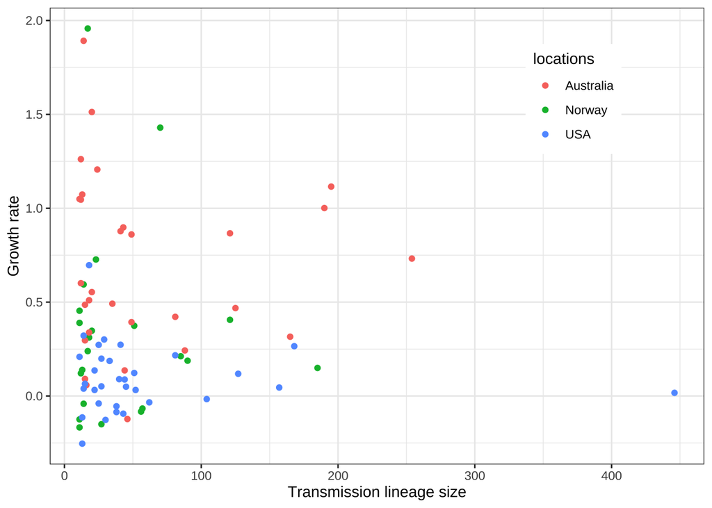

Growth rate versus variables

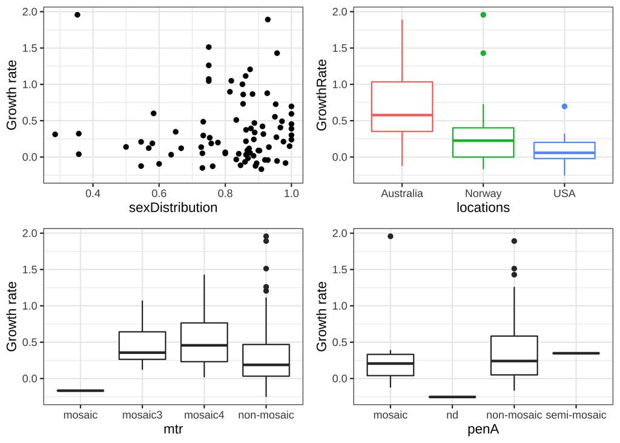

Lineage size versus variables explanatory variables

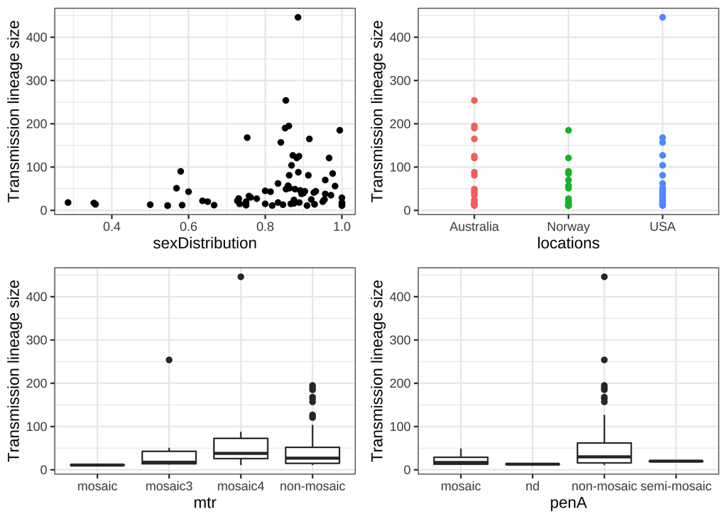

Linear regression of the lineage size and growth rate on the explanatory variables *Note.The model fit is poor, should probably use GLM instead.*

```
##
## Call:
## lm(formula = tlSize ~ penA + mtr + sexDistribution + locations,
##     data = total_data)
##
## Residuals:
##    Min     1Q Median     3Q    Max
## -65.24 -39.59 -23.18   7.45 361.45
##
## Coefficients:
##                 Estimate Std. Error t value Pr(>|t|)
## (Intercept)      -56.825     85.543  -0.664    0.509
## penAnon-mosaic    14.593     30.473   0.479    0.633
## penAsemi-mosaic    2.785     73.342   0.038    0.970
## mtrmosaic3        50.219     74.436   0.675    0.502
## mtrmosaic4        59.007     72.300   0.816    0.417
## mtrnon-mosaic     38.578     70.435   0.548    0.586
## sexDistribution   68.584     50.522   1.358    0.179
## locationsNorway   -9.117     19.818  -0.460    0.647
## locationsUSA       7.040     18.252   0.386    0.701
##
## Residual standard error: 68.19 on 75 degrees of freedom
##   (4 observations deleted due to missingness)
## Multiple R-squared:  0.07467,    Adjusted R-squared:  -0.02403
## F-statistic: 0.7565 on 8 and 75 DF,  p-value: 0.6417
```

```
##
## Call:
## lm(formula = GrowthRate ~ penA + mtr + sexDistribution + locations,
##     data = total_data)
##
## Residuals:
##      Min       1Q   Median       3Q      Max
## -0.78816 -0.23126 -0.03601  0.14285  1.53192
##
## Coefficients:
##                 Estimate Std. Error t value Pr(>|t|)
## (Intercept)      0.36904    0.50702   0.728  0.46902
## penAnon-mosaic   0.12102    0.18317   0.661  0.51088
## penAsemi-mosaic  0.03245    0.43359   0.075  0.94055
## mtrmosaic3       0.46045    0.44004   1.046  0.29884
## mtrmosaic4       0.60570    0.42763   1.416  0.16090
## mtrnon-mosaic    0.50702    0.41695   1.216  0.22789
## sexDistribution -0.37186    0.30998  -1.200  0.23417
## locationsNorway -0.31920    0.11903  -2.682  0.00905 **
## locationsUSA    -0.61096    0.10925  -5.592 3.68e-07 ***
## ---
## Signif. codes:  0 '***' 0.001 '**' 0.01 '*' 0.05 '.' 0.1 ' ' 1
##
## Residual standard error: 0.4031 on 73 degrees of freedom
##   (6 observations deleted due to missingness)
## Multiple R-squared:  0.3311, Adjusted R-squared:  0.2578
## F-statistic: 4.516 on 8 and 73 DF,  p-value: 0.0001721
```

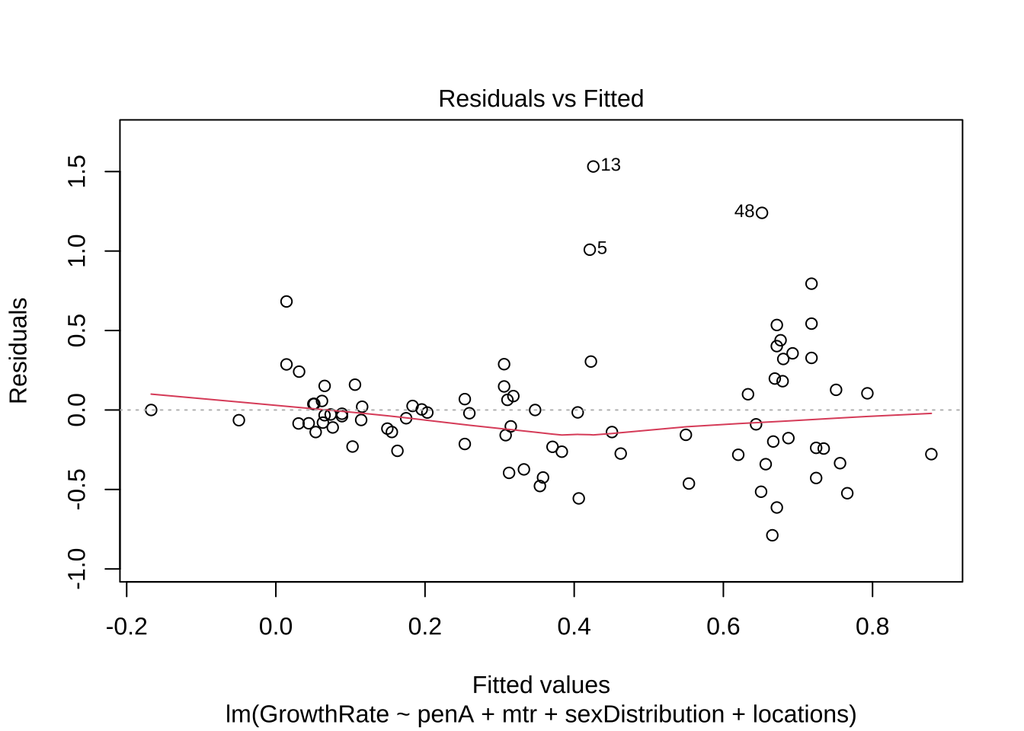

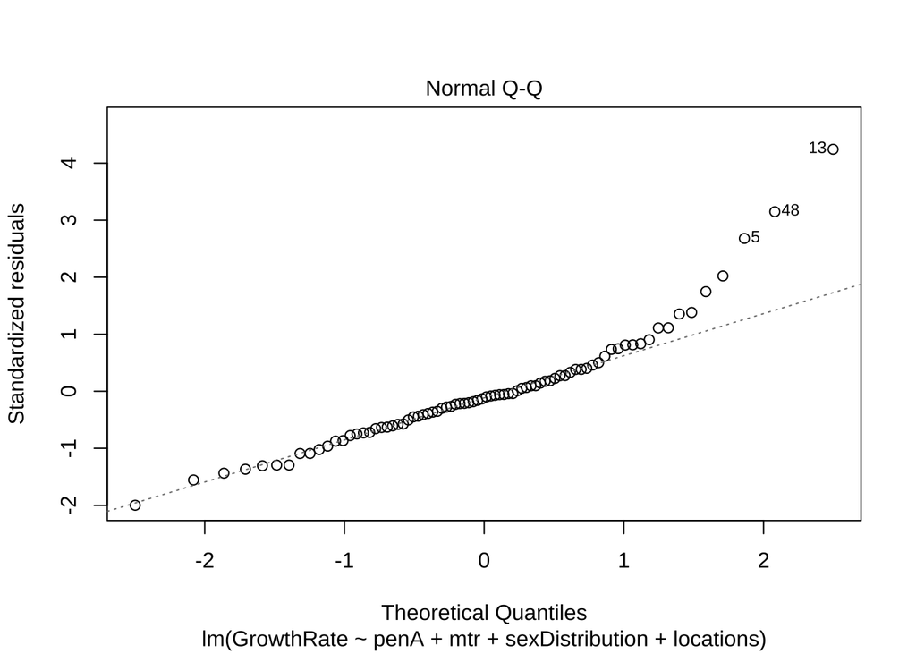

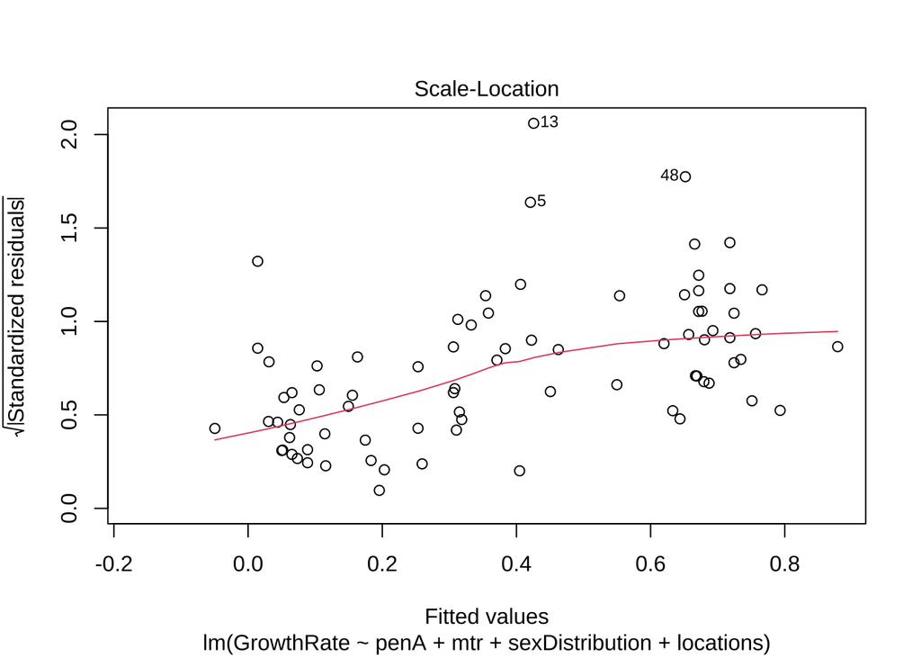

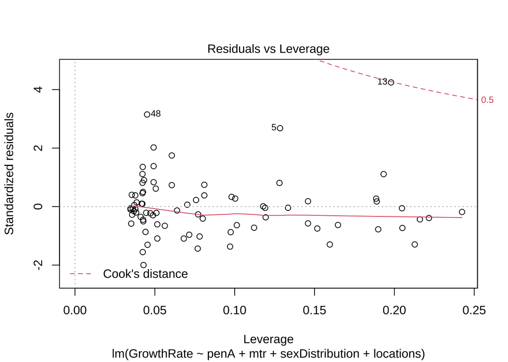

Collapsing the categories into two levels: Mosaic and non mosaic we have the data

```
##
## Call:
## lm(formula = tlSize ~ penA + mtr + sexDistribution + locations,
##     data = total_data_modified)
##
## Residuals:
##    Min     1Q Median     3Q    Max
## -57.43 -38.26 -25.19   7.02 366.45
##
## Coefficients:
##                 Estimate Std. Error t value Pr(>|t|)
## (Intercept)      -0.5397    46.3475  -0.012    0.991
## penAnon-mosaic   13.2094    28.7015   0.460    0.647
## mtrnon-mosaic   -15.0252    18.5581  -0.810    0.421
## sexDistribution  67.8178    49.6155   1.367    0.176
## locationsNorway -12.0549    19.0736  -0.632    0.529
## locationsUSA      6.8264    17.9031   0.381    0.704
##
## Residual standard error: 67.17 on 78 degrees of freedom
##   (4 observations deleted due to missingness)
## Multiple R-squared:  0.06626,    Adjusted R-squared:  0.006405
## F-statistic: 1.107 on 5 and 78 DF,  p-value: 0.3636
```

```
##
## Call:
## lm(formula = GrowthRate ~ penA + mtr + sexDistribution + locations,
##     data = total_data_modified)
##
## Residuals:
##      Min       1Q   Median       3Q      Max
## -0.79384 -0.22193 -0.06251  0.16636  1.54116
##
## Coefficients:
##                 Estimate Std. Error t value Pr(>|t|)
## (Intercept)      0.92624    0.27968   3.312  0.00142 **
## penAnon-mosaic   0.10132    0.17456   0.580  0.56333
## mtrnon-mosaic   -0.02735    0.11138  -0.246  0.80670
## sexDistribution -0.36898    0.30738  -1.200  0.23371
## locationsNorway -0.35228    0.11559  -3.048  0.00317 **
## locationsUSA    -0.60987    0.10821  -5.636 2.81e-07 ***
## ---
## Signif. codes:  0 '***' 0.001 '**' 0.01 '*' 0.05 '.' 0.1 ' ' 1
##
## Residual standard error: 0.401 on 76 degrees of freedom
##   (6 observations deleted due to missingness)
## Multiple R-squared:  0.3106, Adjusted R-squared:  0.2652
## F-statistic: 6.848 on 5 and 76 DF,  p-value: 2.536e-05
```